# ML_CourseProject

Peeyush

February 28, 2018

## Loading the data

```r
rm(list=ls())
trainData <- read.csv("pml-training.csv")
testData <- read.csv("pml-testing.csv")
```

## Exploratory Data Analysis

```r
str(trainData)
```

```
## 'data.frame':    19622 obs. of  160 variables:
##  $ X                       : int  1 2 3 4 5 6 7 8 9 10 ...
##  $ user_name               : Factor w/ 6 levels "adelmo","carlitos",..: 2 2 2 2 2 2 2 2 2 2 ...
##  $ raw_timestamp_part_1    : int  1323084231 1323084231 1323084231 1323084232 1323084232 1323084232 1323084232 1323084232 1323084232 1323084232 ...
##  $ raw_timestamp_part_2    : int  788290 808298 820366 120339 196328 304277 368296 440390 484323 484434 ...
##  $ cvtd_timestamp          : Factor w/ 20 levels "02/12/2011 13:32",..: 9 9 9 9 9 9 9 9 9 9 ...
##  $ new_window              : Factor w/ 2 levels "no","yes": 1 1 1 1 1 1 1 1 1 1 ...
##  $ num_window              : int  11 11 11 12 12 12 12 12 12 12 ...
##  $ roll_belt               : num  1.41 1.41 1.42 1.48 1.48 1.45 1.42 1.42 1.43 1.45 ...
##  $ pitch_belt              : num  8.07 8.07 8.07 8.05 8.07 8.06 8.09 8.13 8.16 8.17 ...
##  $ yaw_belt                : num  -94.4 -94.4 -94.4 -94.4 -94.4 -94.4 -94.4 -94.4 -94.4 -94.4 ...
##  $ total_accel_belt        : int  3 3 3 3 3 3 3 3 3 3 ...
##  $ kurtosis_roll_belt      : Factor w/ 397 levels "","-0.016850",..: 1 1 1 1 1 1 1 1 1 1 ...
##  $ kurtosis_picth_belt     : Factor w/ 317 levels "","-0.021887",..: 1 1 1 1 1 1 1 1 1 1 ...
##  $ kurtosis_yaw_belt       : Factor w/ 2 levels "","#DIV/0!": 1 1 1 1 1 1 1 1 1 1 ...
```

[output cut: 86 more lines]

```r
str(testData)
```

```
## 'data.frame':    20 obs. of  160 variables:
##  $ X                       : int  1 2 3 4 5 6 7 8 9 10 ...
##  $ user_name               : Factor w/ 6 levels "adelmo","carlitos",..: 6 5 5 1 4 5 5 5 2 3 ...
##  $ raw_timestamp_part_1    : int  1323095002 1322673067 1322673075 1322832789 1322489635 1322673149 1322673128 1322673076 1323084240 1322837822 ...
##  $ raw_timestamp_part_2    : int  868349 778725 342967 560311 814776 510661 766645 54671 916313 384285 ...
##  $ cvtd_timestamp          : Factor w/ 11 levels "02/12/2011 13:33",..: 5 10 10 1 6 11 11 10 3 2 ...
##  $ new_window              : Factor w/ 1 level "no": 1 1 1 1 1 1 1 1 1 1 ...
##  $ num_window              : int  74 431 439 194 235 504 485 440 323 664 ...
##  $ roll_belt               : num  123 1.02 0.87 125 1.35 -5.92 1.2 0.43 0.93 114 ...
##  $ pitch_belt              : num  27 4.87 1.82 -41.6 3.33 1.59 4.44 4.15 6.72 22.4 ...
##  $ yaw_belt                : num  -4.75 -88.9 -88.5 162 -88.6 -87.7 -87.3 -88.5 -93.7 -13.1 ...
##  $ total_accel_belt        : int  20 4 5 17 3 4 4 4 4 18 ...
##  $ kurtosis_roll_belt      : logi  NA NA NA NA NA NA ...
##  $ kurtosis_picth_belt     : logi  NA NA NA NA NA NA ...
##  $ kurtosis_yaw_belt       : logi  NA NA NA NA NA NA ...
```

[output cut: 86 more lines]

## Data Creation

```r
dim(trainData)
```

```
## [1] 19622   160
```

```r
dim(testData)
```

```
## [1]  20 160
```

Out of 160 variables starting 7 variables are related to names and times so we remove them from the datasets. Also many variables have NULL values only either in the training set or in test set so they are not useful in model creation so we also remove them all.

```r
#removing time and name variables
trainData <- trainData[,-c(1,2,3,4,5,6,7)]
testData <- testData[ , -c(1,2,3,4,5,6,7)]

#variables that has almost all null values in training set
trainNull<-vector()
for(i in 1:ncol(trainData)){
  if ( any(is.na(trainData[,i]))){
    trainNull <- append(trainNull,i)
  }
}

trainData <- trainData[,-trainNull]
testData <- testData[ , -trainNull]

#variables that has almost all null values in test set
testNull<-vector()
for(i in 1:ncol(testData)){
  if ( any(is.na(testData[,i]))){
    testNull <- append(testNull,i)
  }
}

trainData <- trainData[,-testNull]
testData <- testData[ , -testNull]
```

```r
dim(trainData)
```

```
## [1] 19622    53
```

```r
dim(testData)
```

```
## [1] 20 53
```

Still there are 53 variables so it’s a good idea to perform PCA to reduce number of variables

```r
library(caret)
set.seed(13234)
lastCol<- ncol(trainData)
prePr <- preProcess( x=trainData[,-lastCol], method = "pca")
prePr
```

```
## Created from 19622 samples and 52 variables
##
## Pre-processing:
##   - centered (52)
##   - ignored (0)
##   - principal component signal extraction (52)
##   - scaled (52)
##
## PCA needed 25 components to capture 95 percent of the variance
```

25 PCA components are enough to capture 95% variance. Let’s see how much variance is being captured by different principal components

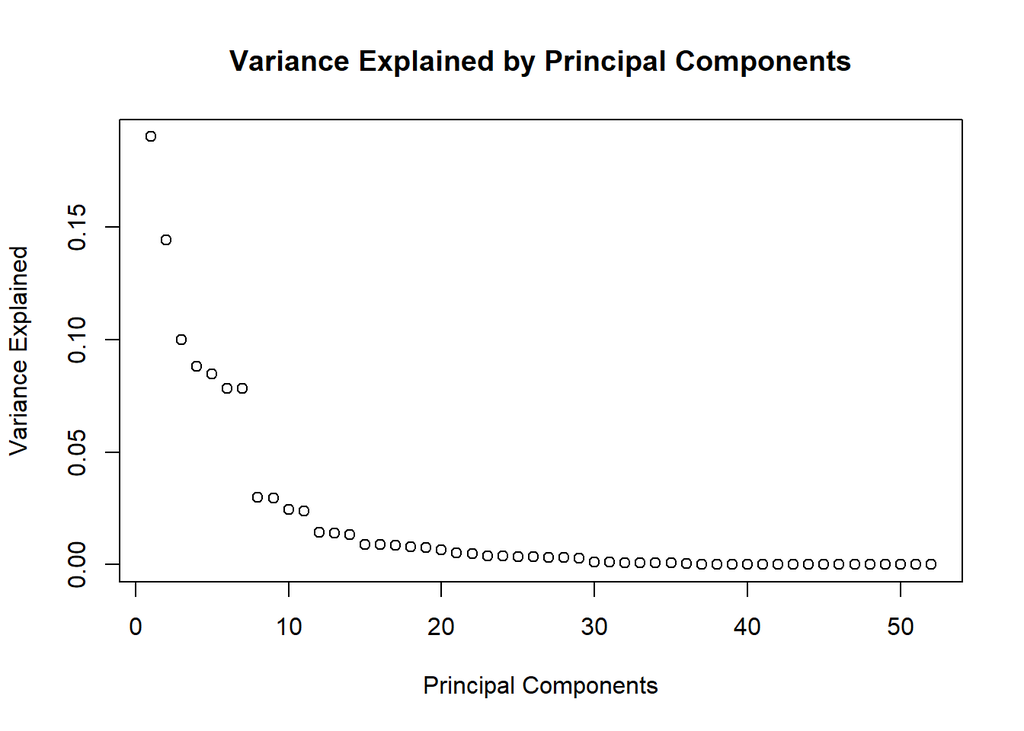

```r
sortedStdIndex<- order(prePr$std,decreasing = TRUE)
std <- prePr$std[sortedStdIndex]
var <- std^2
propVarEx <- var/sum(var)
#propVarEx
plot(propVarEx, xlab="Principal Components", ylab="Variance Explained", main="Variance Explained by Principal Components")
```

```r
#creating new training features based on principal components
trainPCASet<- predict(prePr, trainData[,-lastCol])
dim(trainPCASet)
```

```
## [1] 19622    25
```

```r
#adding the classe variable in the trainingset
trainPCASet$classe <- trainData$classe
```

Only 25 predictors are created by PCA prediction. Transforming test features based on principal components.

```r
#creating new test features based on principal components
testPCASet <- predict(prePr, testData[,-lastCol])
```

We first see with basic decision model when cross validation is not used what is the accuracy

```r
set.seed(10)
baseFit <- train(classe ~.,data=trainPCASet, method="rpart")
#baseFit
confusionMatrix(baseFit)
```

```
## Bootstrapped (25 reps) Confusion Matrix
##
## (entries are percentual average cell counts across resamples)
##
##           Reference
## Prediction    A    B    C    D    E
##          A 23.4 10.5 12.8  6.8  6.8
##          B  0.7  1.1  0.7  0.9  0.9
##          C  2.1  1.7  2.8  1.1  1.2
##          D  1.7  3.1  0.8  5.4  2.2
##          E  0.5  2.9  0.4  2.2  7.3
##
##  Accuracy (average) : 0.4001
```

Accuracy is around *40%*

Because we have total 5 classes so we have to select a multiclass model. We’ll go with decision tree. We will train our model with a repeated cross validation scheme. 10 partitions (folds) will be created 3 times. The parameters will be fine tuned 10 times. Model with optimal Kappa value will be selected every time.

```r
#
set.seed(10)
fit <- train(classe ~.,data=trainPCASet, method="rpart",
             trControl=trainControl(method="repeatedcv",
                                    number=10,
                                    repeats=3),
             metric="Kappa",
             tuneLength =10)
#fit

confusionMatrix(fit)
```

```
## Cross-Validated (10 fold, repeated 3 times) Confusion Matrix
##
## (entries are percentual average cell counts across resamples)
##
##           Reference
## Prediction    A    B    C    D    E
##          A 21.9  7.7  6.7  4.2  3.6
##          B  1.3  5.4  1.1  1.5  2.7
##          C  3.2  2.7  8.5  2.5  2.6
##          D  1.7  2.3  0.7  6.5  1.4
##          E  0.4  1.3  0.4  1.7  8.0
##
##  Accuracy (average) : 0.5032
```

With cross validation the accuracy has improved to *50%.*

How the accuracy improves when we use random forest model, let’s see

```r
set.seed(10)
rfFit <- train(classe ~.,data=trainPCASet, method="rf",
             trControl=trainControl(method="repeatedcv",
                                    number=10,
                                    repeats = 3
                                    ),
             metric="Kappa",
             tuneLength =10,
             ntree=10
             )
#rfFit

confusionMatrix(rfFit)
```

```
## Cross-Validated (10 fold, repeated 3 times) Confusion Matrix
##
## (entries are percentual average cell counts across resamples)
##
##           Reference
## Prediction    A    B    C    D    E
##          A 27.8  0.4  0.1  0.1  0.0
##          B  0.3 18.4  0.4  0.1  0.2
##          C  0.2  0.4 16.6  0.7  0.2
##          D  0.1  0.0  0.3 15.5  0.1
##          E  0.0  0.1  0.1  0.1 17.8
##
##  Accuracy (average) : 0.9603
```

This model gives with same setting over *96% accuracy*

## Predictions

Using our random forest model we will predict classes for all the test cases.

```r
result <- predict(rfFit, testPCASet)
result
```

```
##  [1] B A B A A E D B A A B C B A E E A B B B
## Levels: A B C D E
```